# Przygotowanie danych - projekt

**Zmienne w zbiorze danych:**

- *BeerID* - ID rekordu przepisu na piwo
- *Name* - Nazwa piwa
- *URL* - Adres www w przeglądarce do przepisu na piwo
- *Style* - Nazwa stylu piwa
- *StyleID* - Identyfikator stylu piwa
- *Size.L.* - Ilość warzonego piwa
- *OG* - Ciężar właściwy beczki przed fermentacją
- *FG* - Ciężar właściwy beczki po fermentacji
- *ABV* - Procentowa zawartość alkoholu w piwie
- *IBU* - Międzynarodowa jednostka goryczy w piwie
- *Color* - Standardowa metoda referencyjna koloru piwa: 0 - jasne, 50 - ciemne
- *BoilSize* - Ilość cieczy na początku wrzenia
- *BoilTime* - Czas warzenia piwa
- *BoilGravity* - Ciężar właściwy beczki przed zagotowaniem
- *Efficiency* - Skuteczność ekstrakcji zacieru piwnego - ekstrakcja cukrów z ziarna podczas zacierania
- *MashThickness* - Ilość wody na funt ziarna
- *SugarScale* - Skala do określenia stężenia rozpuszczonych ciał stałych w beczce
- *BrewMethod* - Technika warzenia piwa
- *PitchRate* - Drożdże dodawane do fermentora na jednostkę grawitacyjną - m komórek/ml/deg P
- *PrimaryTemp* - Temperatura na etapie fermentacji w stopniach Celsjusza
- *PrimaryMethod* - Metoda gruntowania
- *PrimingAmount* - Ilość użytego cukru gruntującego
- *UserId* - ID użytkownikia

**Potrzebne pakiety**

```r
library('dplyr')
library('ggplot2')
library('car')
library('VIM')
library('readxl')
library('gridExtra')
library('corrplot')
library('EnvStats')
library('psych')
library('sampling')
```

**Wczytanie danych**

```r
dane <- read.csv("C:/Users/domin/OneDrive/Pulpit/UG mgr/2 sem/Przygotowanie danych - ĆW/PROJEKT/recipeData.csv", sep = ",")
danes <- read.csv("C:/Users/domin/OneDrive/Pulpit/UG mgr/2 sem/Przygotowanie danych - ĆW/PROJEKT/styleData.csv", sep = ";")
```

*Zamiana okresleń “N/A” na faktyczne braki*

```r
head(is.na(dane),10)
```

```
##       BeerID  Name   URL Style StyleID Size.L.    OG    FG   ABV   IBU Color
##  [1,]  FALSE FALSE FALSE FALSE   FALSE   FALSE FALSE FALSE FALSE FALSE FALSE
##  [2,]  FALSE FALSE FALSE FALSE   FALSE   FALSE FALSE FALSE FALSE FALSE FALSE
##  [3,]  FALSE FALSE FALSE FALSE   FALSE   FALSE FALSE FALSE FALSE FALSE FALSE
##  [4,]  FALSE FALSE FALSE FALSE   FALSE   FALSE FALSE FALSE FALSE FALSE FALSE
##  [5,]  FALSE FALSE FALSE FALSE   FALSE   FALSE FALSE FALSE FALSE FALSE FALSE
##  [6,]  FALSE FALSE FALSE FALSE   FALSE   FALSE FALSE FALSE FALSE FALSE FALSE
##  [7,]  FALSE FALSE FALSE FALSE   FALSE   FALSE FALSE FALSE FALSE FALSE FALSE
##  [8,]  FALSE FALSE FALSE FALSE   FALSE   FALSE FALSE FALSE FALSE FALSE FALSE
##  [9,]  FALSE FALSE FALSE FALSE   FALSE   FALSE FALSE FALSE FALSE FALSE FALSE
## [10,]  FALSE FALSE FALSE FALSE   FALSE   FALSE FALSE FALSE FALSE FALSE FALSE
##       BoilSize BoilTime BoilGravity Efficiency MashThickness SugarScale
##  [1,]    FALSE    FALSE       FALSE      FALSE         FALSE      FALSE
##  [2,]    FALSE    FALSE       FALSE      FALSE         FALSE      FALSE
##  [3,]    FALSE    FALSE       FALSE      FALSE         FALSE      FALSE
```

[output cut: 18 more lines]

```r
dane<-replace(dane, dane == "N/A", NA)
head(dane,10)
```

```
##    BeerID                                         Name
## 1       1                            Vanilla Cream Ale
## 2       2                  Southern Tier Pumking clone
## 3       3                  Zombie Dust Clone - EXTRACT
## 4       4                Zombie Dust Clone - ALL GRAIN
## 5       5              Bakke Brygg Belgisk Blonde 50 l
## 6       6                 Sierra Nevada Pale Ale Clone
## 7       7     Russian River Pliny the Elder (original)
## 8       8 Spotted Clown (New Glarus Spotted Cow clone)
## 9       9                     Chocolate Vanilla Porter
## 10     10                           Mango Habanero IPA
##                                                                      URL
## 1                           /homebrew/recipe/view/1633/vanilla-cream-ale
## 2                /homebrew/recipe/view/16367/southern-tier-pumking-clone
## 3                   /homebrew/recipe/view/5920/zombie-dust-clone-extract
```

[output cut: 51 more lines]

```r
head(danes,10)
```

```
##                     Style StyleID
## 1                 Altbier       1
## 2  Alternative Grain Beer       2
## 3  Alternative Sugar Beer       3
## 4      American Amber Ale       4
## 5     American Barleywine       5
## 6      American Brown Ale       6
## 7            American IPA       7
## 8          American Lager       8
## 9    American Light Lager       9
## 10      American Pale Ale      10
```

*1.Określenie celu badania:*

Celem badania jest przygotowanie zbioru danych do przeprowadzenia estymacji modelu liniowego (regresji liniowej) objaśniającego procentową zawartość alkoholu (zmienna objaśniana - ABV) na podstawie innych zmiennych ze zbioru.

*2. Opisanie każdej z zmiennych znajdujących się w zbiorze:*

**a. Skala pomiarowa**

**b. Jednostka miary**

**d. Prosta wizualizacja zmiennych**

**BeerID -> skala nominalna -> bez jednostki miary**

```r
dane$BeerID <- as.factor(dane$BeerID)
head(table(dane$BeerID),10)
```

```
##
##  1  2  3  4  5  6  7  8  9 10
##  1  1  1  1  1  1  1  1  1  1
```

```r
#Brak wizualizacji, ponieważ każda liczba, która jest etykietą danego piwa jest powtórzona jeden raz
```

**Name -> skala nominalna-> bez jednostki miary**

```r
dane$Name<-as.factor(dane$Name)
head(table(dane$Name),10)
```

```
##
##         '  #1 All American Liberty Lager
##                                        1
##              ' #1 A Copper Head Road Ale
##                                        1
##                    ' #1 A Red Head Wheat
##                                        1
##                         ' #1 Amber lager
##                                        1
##                  ' #1 American Blond Ale
##                                        1
##       ' #1 American Extra Light Pale Ale
##                                        1
##           ' #1 American Honey orange Ale
##                                        1
## ' #1 American pale ale w/grapefruit zest
##                                        1
##     ' #1 American wheat with orange zest
##                                        1
##              ' #1 Big Cock Bock of Texas
##                                        1
```

```r
#Brak wizualizacji, ponieważ nie można pokazać tego typu zmiennych na wykresie
```

**URL -> skala nominalna -> bez jednostki miary**

```r
dane$URL<-as.factor(dane$URL)
head(table(dane$URL),10)
```

```
##
##                           /homebrew/recipe/view/10003/yuen-porter-clone
##                                                                       1
##                       /homebrew/recipe/view/100034/double-dog-citra-ipa
##                                                                       1
##                                 /homebrew/recipe/view/100068/hop-rocket
##                                                                       1
##                           /homebrew/recipe/view/100096/evie-pale-ale-ag
##                                                                       1
##                          /homebrew/recipe/view/100147/battle-of-flodden
##                                                                       1
##                              /homebrew/recipe/view/10022/california-apa
##                                                                       1
##                   /homebrew/recipe/view/100221/belgian-double-black-ipa
##                                                                       1
##               /homebrew/recipe/view/100334/sierra-nevada-pale-ale-clone
##                                                                       1
##                            /homebrew/recipe/view/10040/pineapple-sagepa
##                                                                       1
## /homebrew/recipe/view/100434/zanzibar-chocolate-espresso-imperial-stout
##                                                                       1
```

```r
#Brak wizualizacji, ponieważ nie można pokazać tego typu zmiennych na wykresie
```

**Style -> skala nominalna -> bez jednostki miary**

```r
dane$Style<-as.factor(dane$Style)
head(table(dane$Style),10)
```

```
##
##                Altbier Alternative Grain Beer Alternative Sugar Beer
##                    137                     36                     21
##     American Amber Ale    American Barleywine     American Brown Ale
##                   2038                    341                   1152
##           American IPA         American Lager   American Light Lager
##                  11940                    220                   2277
##      American Pale Ale
##                   7581
```

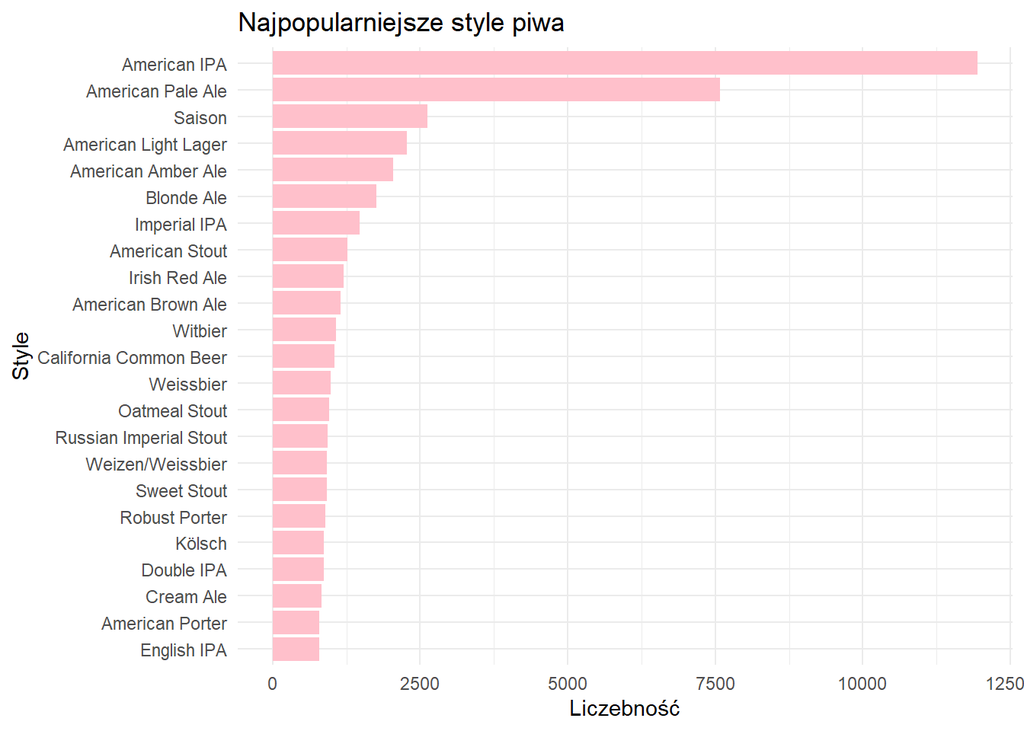

```r
dane %>%
  group_by(Style) %>%
  filter(n() > 700) %>%
  mutate(count = n()) %>%
  ggplot(aes(x = reorder(Style, count))) +
  geom_bar(fill = 'pink') +
  coord_flip() +
  theme_minimal() +
  labs(x = 'Style', y = 'Liczebność', title = "Najpopularniejsze style piwa")
```

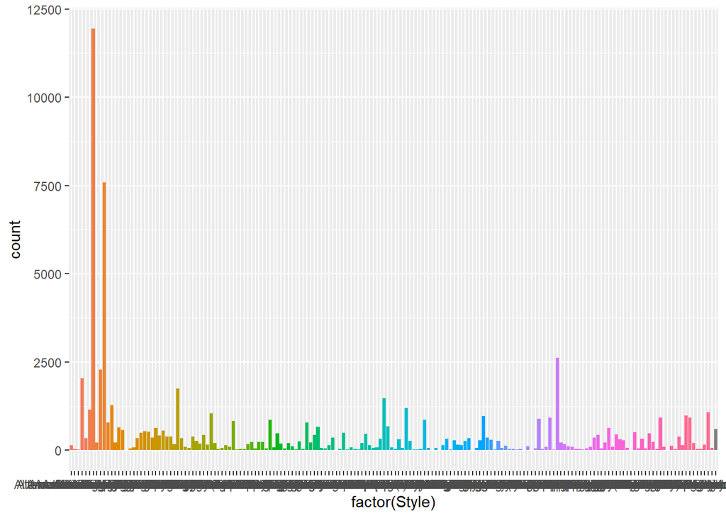

```r
ggplot(dane , aes(x=factor(Style), fill=factor(Style))) +
  geom_bar() +
  theme(legend.position="none")
```

**StyleID - skala nominalna -> bez jednostki miary**

```r
head(table(dane$StyleID),10)
```

```
##
##     1     2     3     4     5     6     7     8     9    10
##   137    36    21  2038   341  1152 11940   220  2277  7581
```

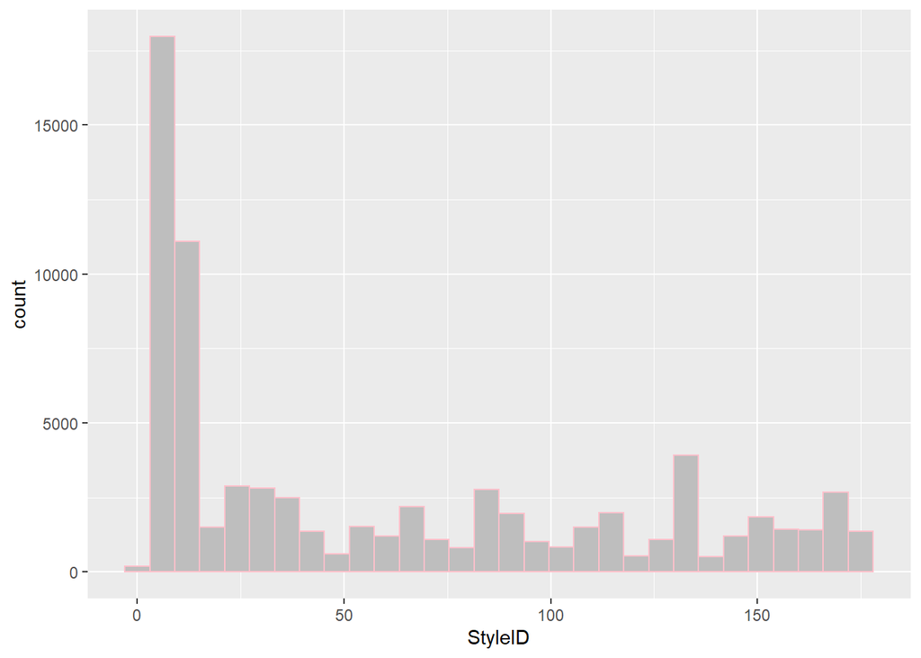

```r
ggplot(dane, aes(x=StyleID)) +
  geom_histogram(color="pink", fill="grey")
```

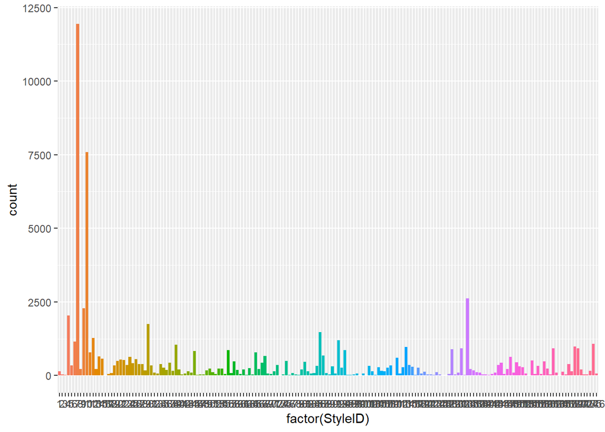

```r
ggplot(dane , aes(x=factor(StyleID), fill=factor(StyleID))) +
  geom_bar() +
  theme(legend.position="none")
```

**Size.L. - skala ilorazowa -> wyrażone w litrach**

```r
dane$Size.L.<-as.numeric(dane$Size.L.)
mean(dane$Size.L., na.rm='TRUE')
```

```
## [1] 43.92977
```

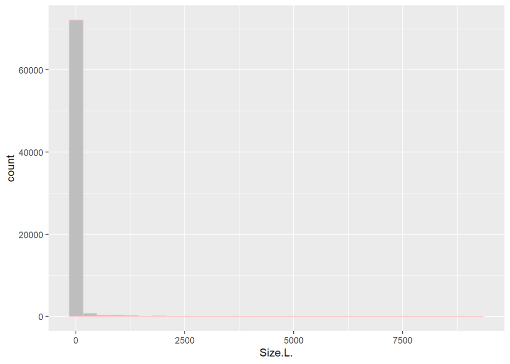

```r
ggplot(dane, aes(x=Size.L.)) +
  geom_histogram(color="pink", fill="grey")
```

**OG -> skala ilorazowa -> wyrażona w kN/m^3 (ciężar właświy - po konwersji jednostek będących w innej skali)**

```r
#funkcja odpowiadająca za zamianę jednostek do jednej z dwóch skali, w której podana jest zmienna
convog <- function(x) {
  return(1+ (x / (258.6 - ( (x/258.2) *227.1) )))
  }

for ( i in  1 : nrow(dane) )  {
  if (dane$SugarScale[i] >= 'Plato') {
    dane$OG[i] = convog(dane$OG[i])
  }
}

dane$OG<-round(dane$OG,3)
dane$OG<-as.numeric(dane$OG)
mean(dane$OG, na.rm='TRUE')
```

```
## [1] 1.00542
```

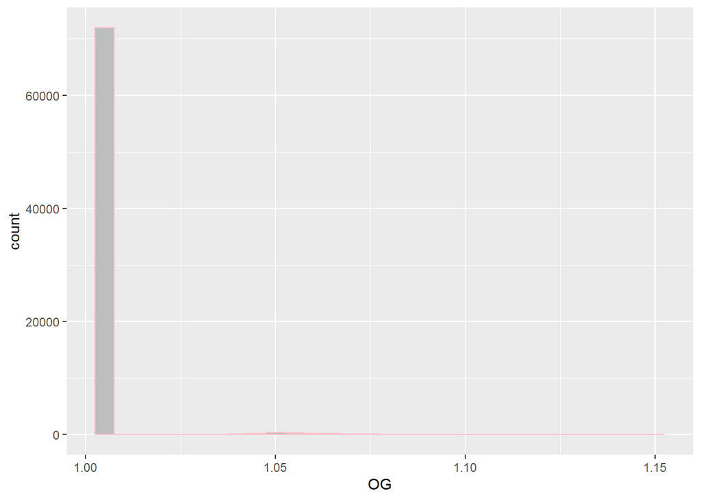

```r
ggplot(dane, aes(x=OG)) +
  geom_histogram(color="pink", fill="grey")
```

**FG-> skala ilorazowa -> wyrażona w kN/m^3(ciężar właświy - po konwersji jednostek będących w innej skali)**

```r
#funkcja odpowiadająca za zamianę jednostek do jednej z dwóch skali, w której podana jest zmienna
convog <- function(x) {
  return(1+ (x / (258.6 - ( (x/258.2) *227.1) )))
  }

for ( i in  1 : nrow(dane) )  {
  if (dane$SugarScale[i] >= 'Plato') {
    dane$FG[i] = convog(dane$FG[i])
  }
}

dane$FG<-round(dane$FG,3)
dane$FG<-as.numeric(dane$FG)
mean(dane$FG, na.rm='TRUE')
```

```
## [1] 1.004242
```

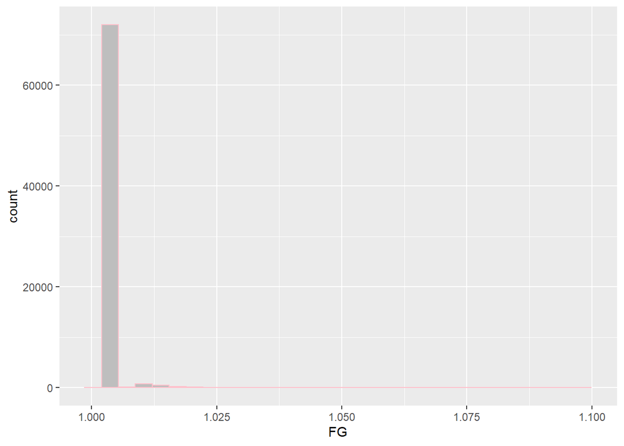

```r
ggplot(dane, aes(x=FG)) +
  geom_histogram(color="pink", fill="grey")
```

**ABV-> skala ilorazowa -> wyrażona w procentach**

```r
dane$ABV<-as.numeric(dane$ABV)
mean(dane$ABV, na.rm='TRUE')
```

```
## [1] 6.136865
```

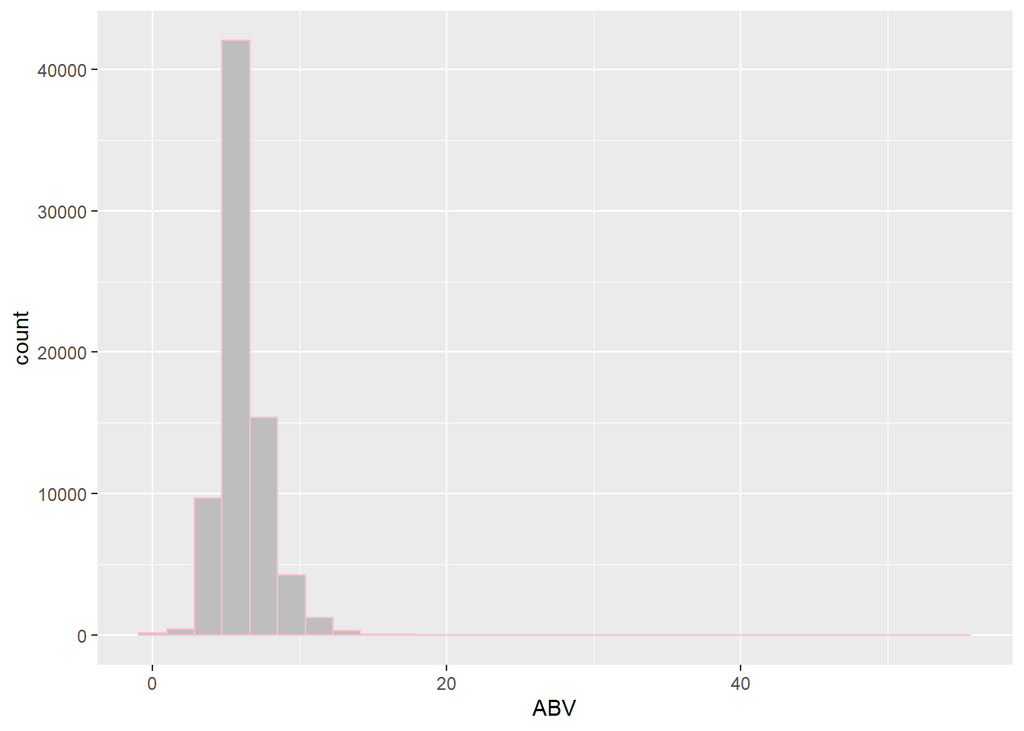

```r
ggplot(dane, aes(x=ABV)) +
  geom_histogram(color="pink", fill="grey")
```

**IBU-> skala przedziałowa -> jednostki IBU**

```r
head(table(dane$IBU),10)
```

```
##
##    0 0.01 0.04 0.08 0.13 0.14 0.18  0.2 0.23  0.3
## 4159    1    1    1    1    2    2    1    1    1
```

```r
#Pokazanie skali jednostek IBU w innej formie
dane$IBU_1 <- recode(dane$IBU, "8:20 ='8-20'; 16.1:25 ='16-25'; NA=NA; 18.1:28='18-28';18.1:30='18-30';20.1:40='20-40';25.1:50='25-50';
                       20.1:40='20-40+';30.1:45='30-45+';40.1:60='40-60+';else='40-120+'")
head(table(dane$IBU_1),10)
```

```
##
##   16-25   18-28   18-30   20-40   25-50 40-120+  40-60+    8-20
##    7333    4565    3031   13801    9146   21545    5926    8514
```

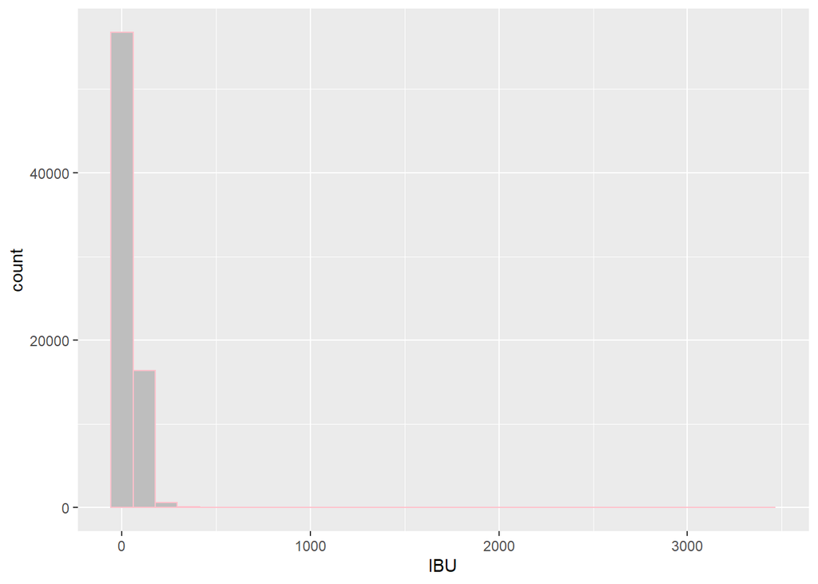

```r
ggplot(dane, aes(x=IBU)) +
  geom_histogram(color="pink", fill="grey")
```

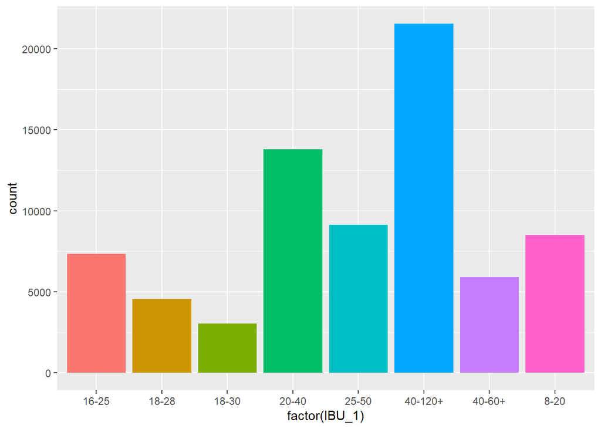

```r
ggplot(dane , aes(x=factor(IBU_1), fill=factor(IBU_1))) +
  geom_bar() +
  theme(legend.position="none")
```

**Color ->skala przedziałowa -> jednostka SRM**

```r
head(table(dane$Color),10)
```

```
##
##    0 0.02 0.03 0.11 0.14 0.18 0.28 0.31 0.33 0.41
##  101    2    1    1    1    2    1    3    1    1
```

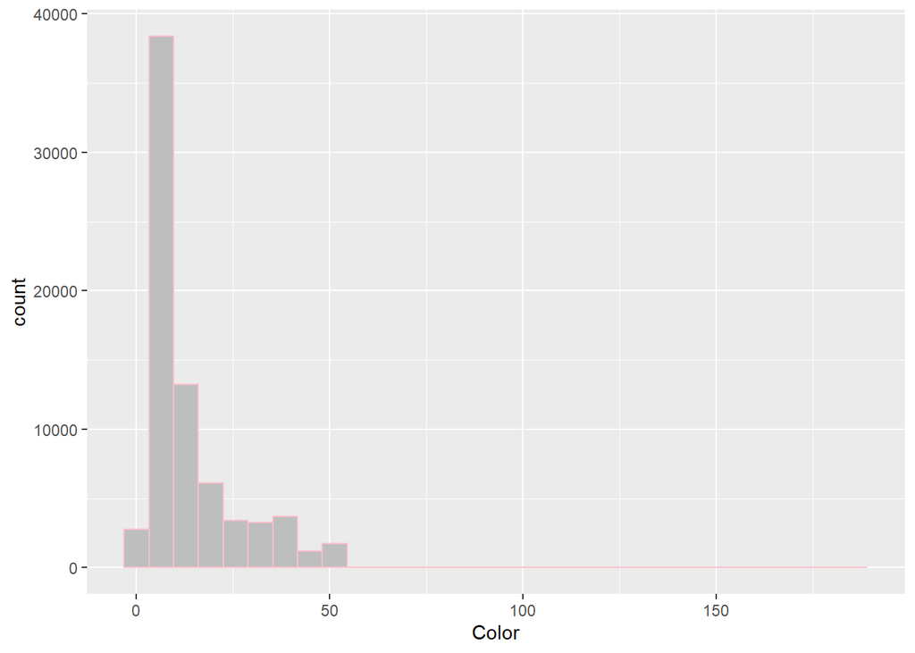

```r
ggplot(dane, aes(x=Color)) +
  geom_histogram(color="pink", fill="grey")
```

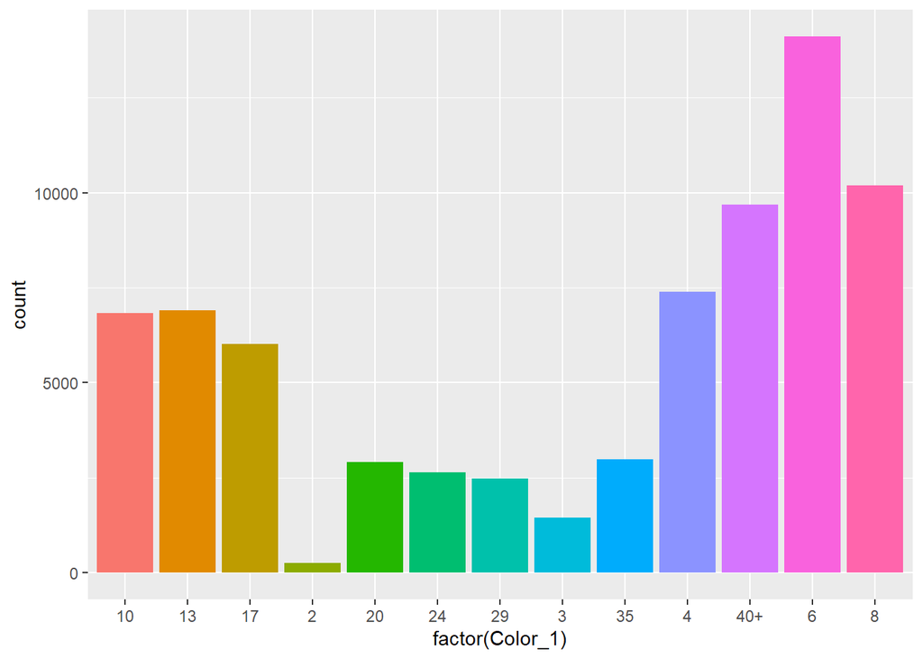

```r
#Pokazanie skali koloru w innej formie
dane$Color_1 <- recode(dane$Color, "0:2 ='2'; 2.1:3 ='3'; NA=NA;3.1:4='4';4.1:6='6';6.1:8='8';8.1:10='10';10.1:13='13';13.1:17='17';17.1:20='20';20.1:24='24';24.1:29='29';29.1:35='35'; else ='40+'")

ggplot(dane , aes(x=factor(Color_1), fill=factor(Color_1))) +
  geom_bar() +
  theme(legend.position="none")
```

**BoilSize -> skala ilorazowa -> wyrażone w litrach**

```r
dane$BoilSize<-as.numeric(dane$BoilSize)
mean(dane$BoilSize, na.rm='TRUE')
```

```
## [1] 49.72492
```

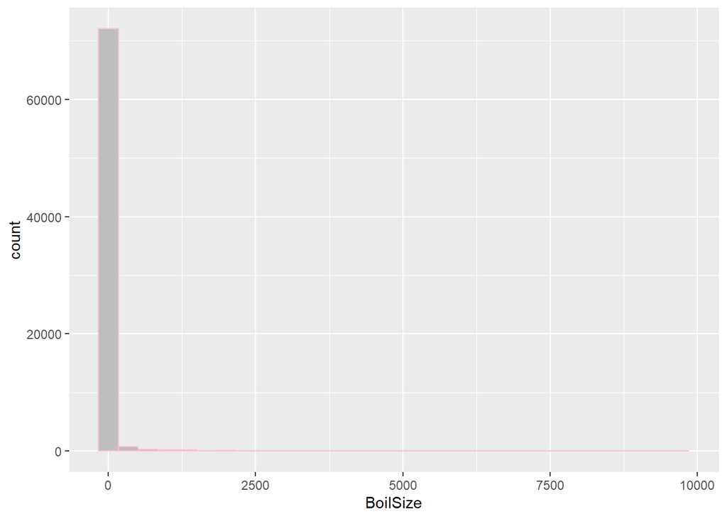

```r
ggplot(dane, aes(x=BoilSize)) +
  geom_histogram(color="pink", fill="grey")
```

**BoilTime -> skala ilorazowa -> jednostka: minuty**

```r
dane$BoilTime<-as.numeric(dane$BoilTime)
mean(dane$BoilTime, na.rm='TRUE')
```

```
## [1] 65.07487
```

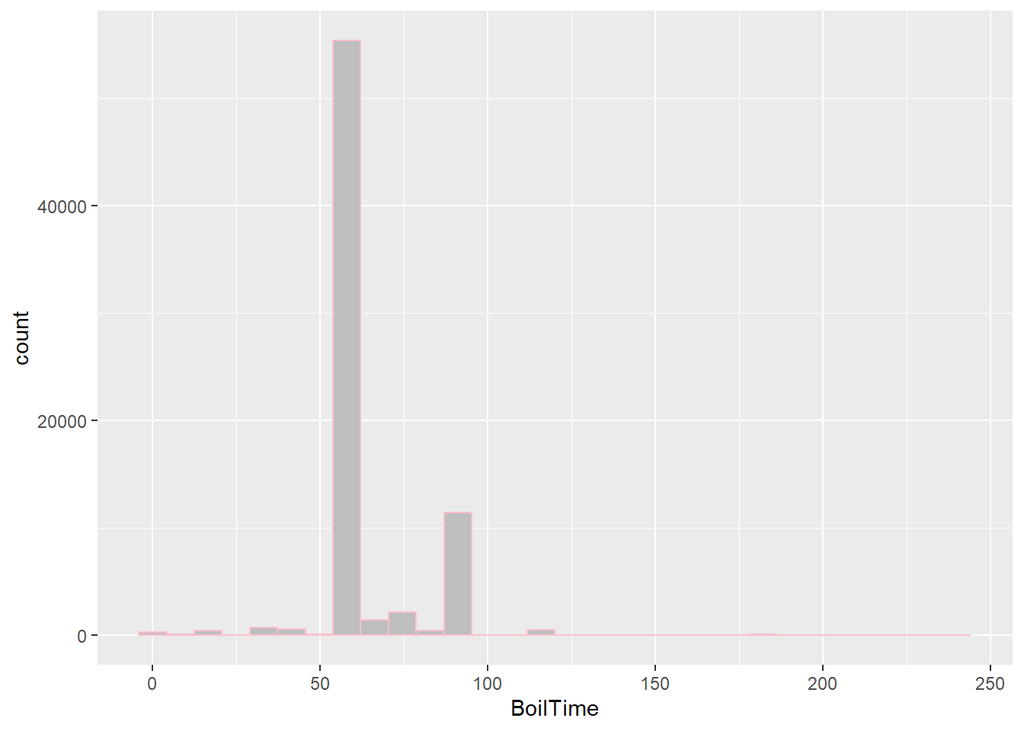

```r
ggplot(dane, aes(x=BoilTime)) +
  geom_histogram(color="pink", fill="grey")
```

**BoilGravity -> skala ilorazowa -> wyrażona w kN/m^3(ciężar właświy - po konwersji jednostek będących w innej skali)**

```r
dane$BoilGravity <- as.numeric(dane$BoilGravity)

#funkcja odpowiadająca za zamianę jednostek do jednej z dwóch skali, w której podana jest zmienna
convog <- function(x) {
  return(1+ (x / (258.6 - ( (x/258.2) *227.1) )))
  }

for ( i in  1 : nrow(dane) )  {
  if (dane$SugarScale[i] >= 'Plato') {
    dane$BoilGravity[i] = convog(dane$BoilGravity[i])
  }
}
dane$BoilGravity<-round(dane$BoilGravity,3)
mean(dane$BoilGravity, na.rm='TRUE')
```

```
## [1] 1.005234
```

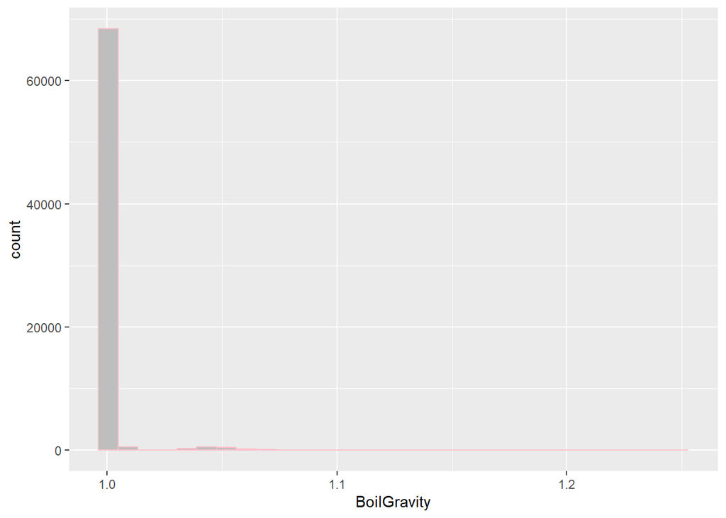

```r
ggplot(dane, aes(x=BoilGravity)) +
  geom_histogram(color="pink", fill="grey")
```

**Efficiency-> skala przedziałowa -> jednostka miary: procenty**

```r
head(table(dane$Efficiency),10)
```

```
##
##   0 0.8   1   2 2.4   5 6.3 6.6 7.5   8
## 101   2   7   1   1  26   1   1   1   1
```

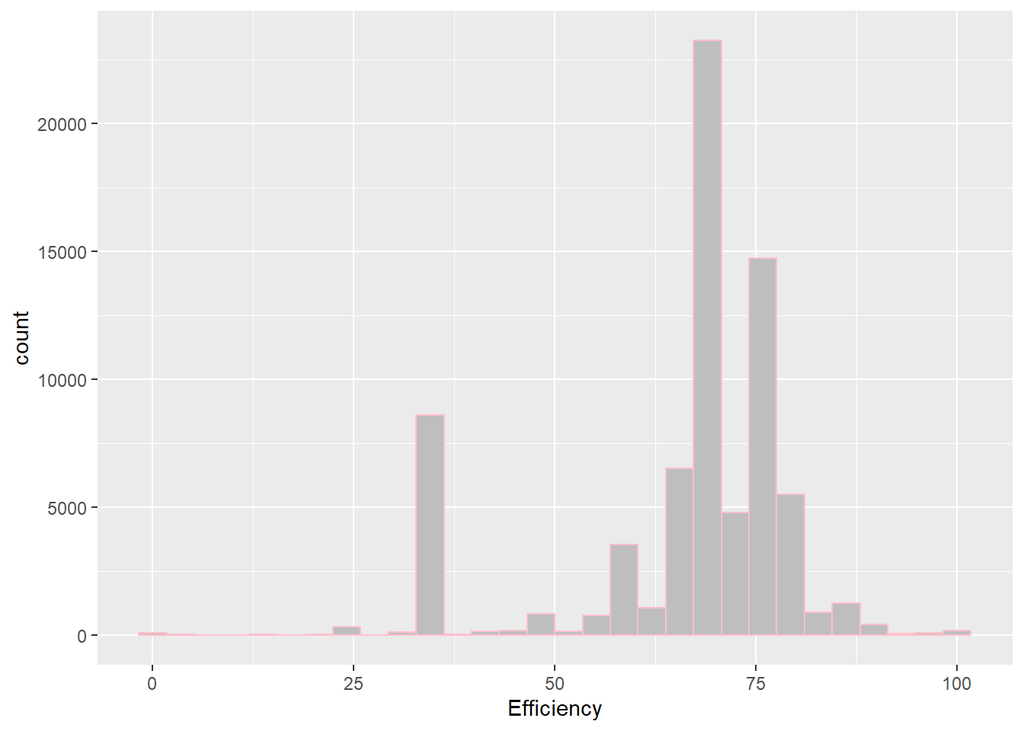

```r
ggplot(dane, aes(x=Efficiency)) +
  geom_histogram(color="pink", fill="grey")
```

```r
#Przedstawienie zmiennej w innej formie
dane$Efficiency_1 <- recode(dane$Efficiency, "0:10 ='0-10'; 10.1:20 ='10-20'; NA=NA; 20.1:30='20-30';30.1:40='30-40';40.1:50='40-50';
                        50.1:60='50-60';60.1:70='60-70';70.1:80='70-80';80.1:90='80-90';else='90-100'")
table(dane$Efficiency_1)
```

```
##
##   0-10  10-20  20-30  30-40  40-50  50-60  60-70  70-80  80-90 90-100
##    165     67    461   8787   1042   4497  30837  24866   2767    372
```

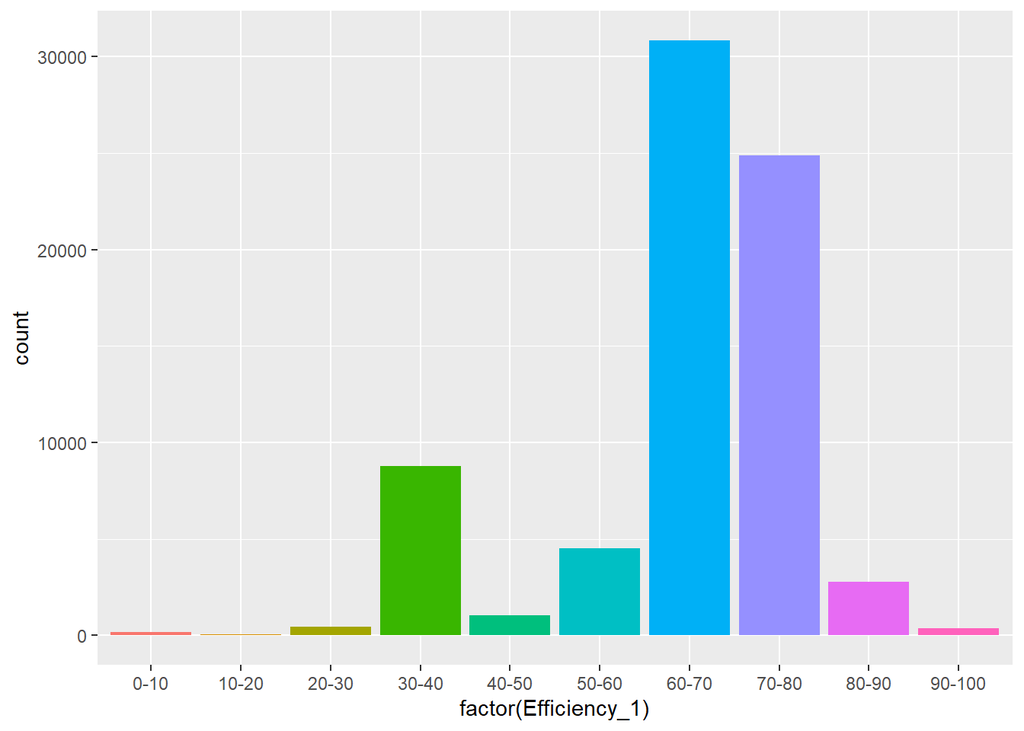

```r
ggplot(dane , aes(x=factor(Efficiency_1), fill=factor(Efficiency_1))) +
  geom_bar() +
  theme(legend.position="none")
```

**MashThickness -> skala ilorazowa -> wyrażone w litrach**

```r
dane$MashThickness <- as.numeric(dane$MashThickness)
mean(dane$MashThickness, na.rm='TRUE')
```

```
## [1] 2.127235
```

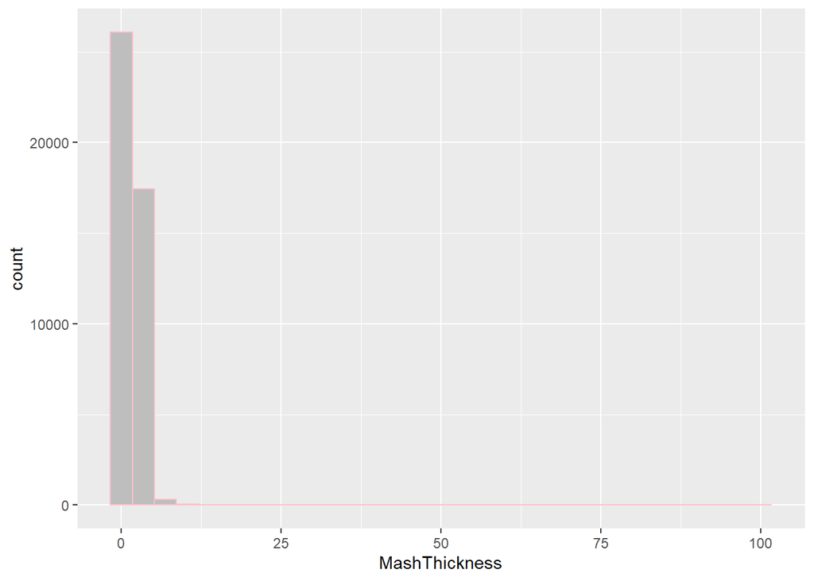

```r
ggplot(dane, aes(x=MashThickness)) +
  geom_histogram(color="pink", fill="grey")
```

**SugarScale -> skala nominalna: dychotomiczna -> brak jednostki miary**

```r
dane$SugarScale<-as.factor(dane$SugarScale)
head(table(dane$SugarScale),50)
```

```
##
##            Plato Specific Gravity
##             1902            71959
```

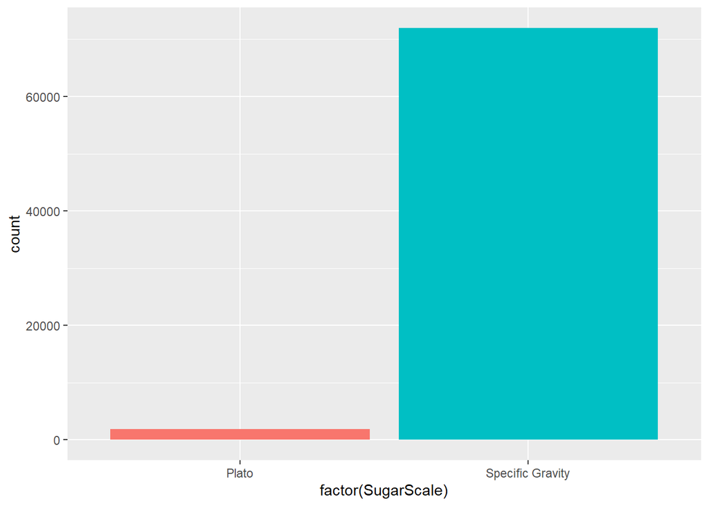

```r
ggplot(dane , aes(x=factor(SugarScale), fill=factor(SugarScale))) +
  geom_bar() +
  theme(legend.position="none")
```

**BrewMethod -> skala nominalna (4 warianty)-> brak jednostki miary**

```r
dane$BrewMethod<-as.factor(dane$BrewMethod)
head(table(dane$BrewMethod),10)
```

```
##
##    All Grain         BIAB      extract Partial Mash
##        49692        12016         8626         3527
```

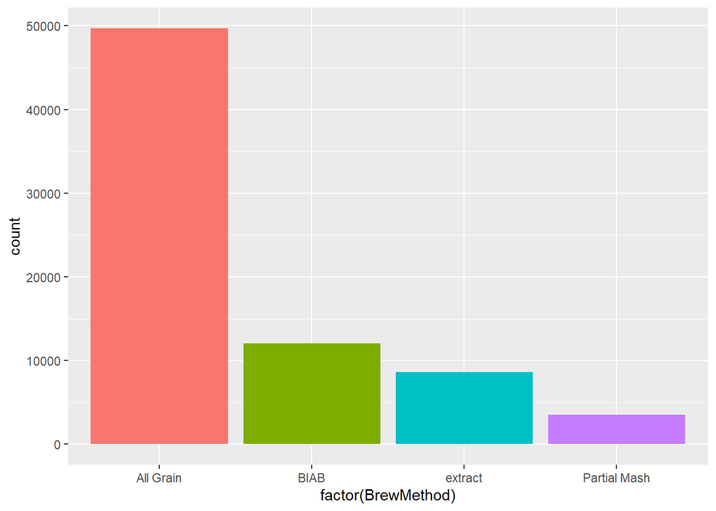

```r
ggplot(dane , aes(x=factor(BrewMethod), fill=factor(BrewMethod))) +
  geom_bar() +
  theme(legend.position="none")
```

**PitchRate -> skala ilorazowa -> jednostka miary: m komórek/ml/deg P**

```r
dane$PitchRate <- as.numeric(dane$PitchRate)
mean(dane$PitchRate, na.rm='TRUE')
```

```
## [1] 0.7504681
```

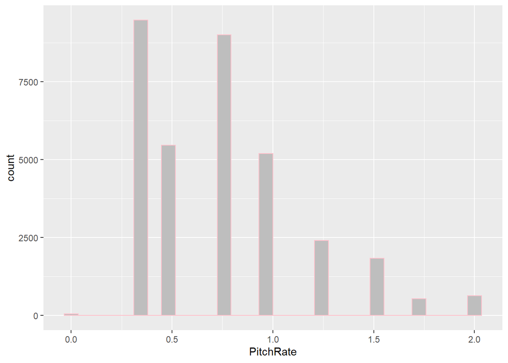

```r
ggplot(dane, aes(x=PitchRate)) +
  geom_histogram(color="pink", fill="grey")
```

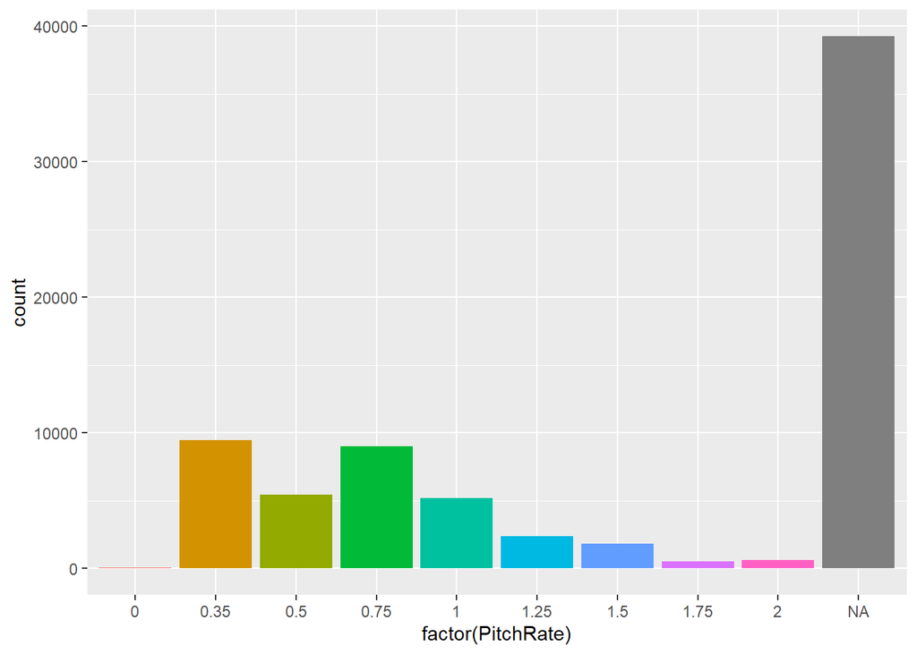

```r
ggplot(dane , aes(x=factor(PitchRate), fill=factor(PitchRate))) +
  geom_bar() +
  theme(legend.position="none")
```

**PrimaryTemp -> skala przedziałowa -> jednostka miary: temperatura w stopniach Celsjusza**

```r
dane$PrimaryTemp<-as.numeric(dane$PrimaryTemp)
head(table(dane$PrimaryTemp),10)
```

```
##
## -17.78 -14.44 -13.89 -12.22 -10.56  -9.44  -8.89  -8.33  -7.78  -7.22
##     44      1      1      2      1      1      2      1     11      9
```

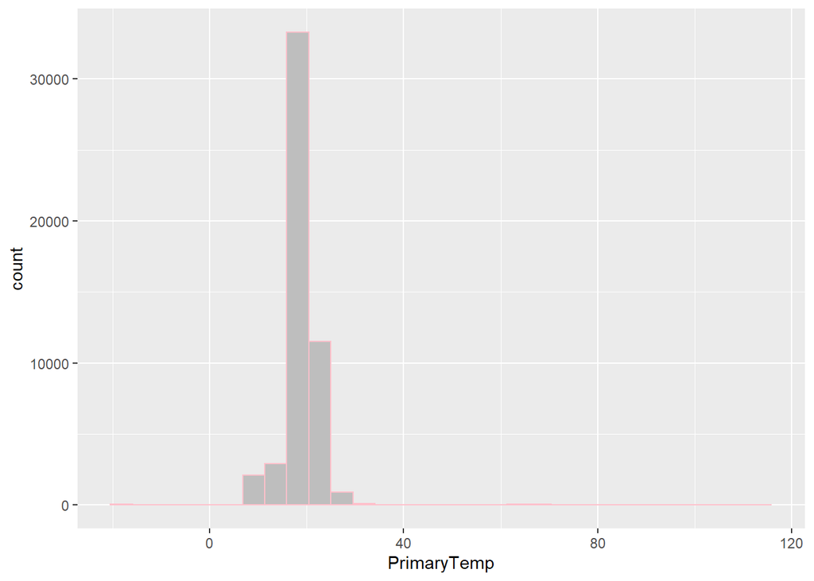

```r
ggplot(dane, aes(x=PrimaryTemp)) +
  geom_histogram(color="pink", fill="grey")
```

```r
#Przedstawienie zmiennej w innej formie
dane$PrimaryTemp_1 <- recode(dane$Efficiency, "-20:0 ='<0'; 0.1:50 ='0-50';50.1:60 ='50-60';60.1:70 ='60-70';70.1:100='70>';else='NA'")
table(dane$PrimaryTemp_1)
```

```
##
##    <0  0-50 50-60 60-70   70>
##   101 10421  4497 30837 28005
```

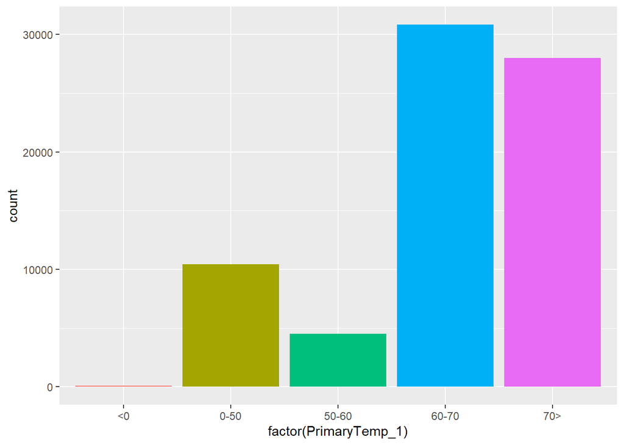

```r
ggplot(dane , aes(x=factor(PrimaryTemp_1), fill=factor(PrimaryTemp_1))) +
  geom_bar() +
  theme(legend.position="none")
```

**PrimingMethod -> skala nominalna -> brak jednostki miary**

```r
dane$PrimingMethod<-as.factor(dane$PrimingMethod)
head(table(dane$PrimingMethod),10)
```

```
##
##                         ??????  40g/5 US G / 19L. -Brew sugar
##                              1                              1
##                     Corn Sugar               Corn Sugar/Water
##                              2                              1
##            Grade A maple syrup                         ??????
##                              1                              1
##                      ?????????               1 cooperstablett
##                              1                              1
##                          1 cup              100 g de dextrose
##                              1                              1
```

```r
#Brak wizualizacji, ponieważ nie można pokazać tego typu zmiennych na wykresie
```

**PrimingAmount -> skala ilorazowa -> jednostki miary: różne**

```r
dane$PrimingAmount<-as.factor(dane$PrimingAmount)
head(table(dane$PrimingAmount),10)
```

```
##
##                          ---                     @ 15 psi
##                            1                            1
##  2.1 vol. CO2(typ. of style)              25g table sugar
##                            1                            1
##                       4.0 oz                      4.2 oz.
##                            1                            1
##               5 5 g sukker/L                         6g/l
##                            1                            1
##                Then Nitro#30                (1.5-2.5vols)
##                            1                            1
```

```r
#Brak wizualizacji, ponieważ nie można pokazać tego typu zmiennych na wykresie
```

**UserId -> skala nominalna -> brak jednostki miary**

```r
head(table(dane$UserId),10)
```

```
##
##  49  87  97 116 136 145 152 157 177 196
##   2   6  21   3   6   5   6   1   2   5
```

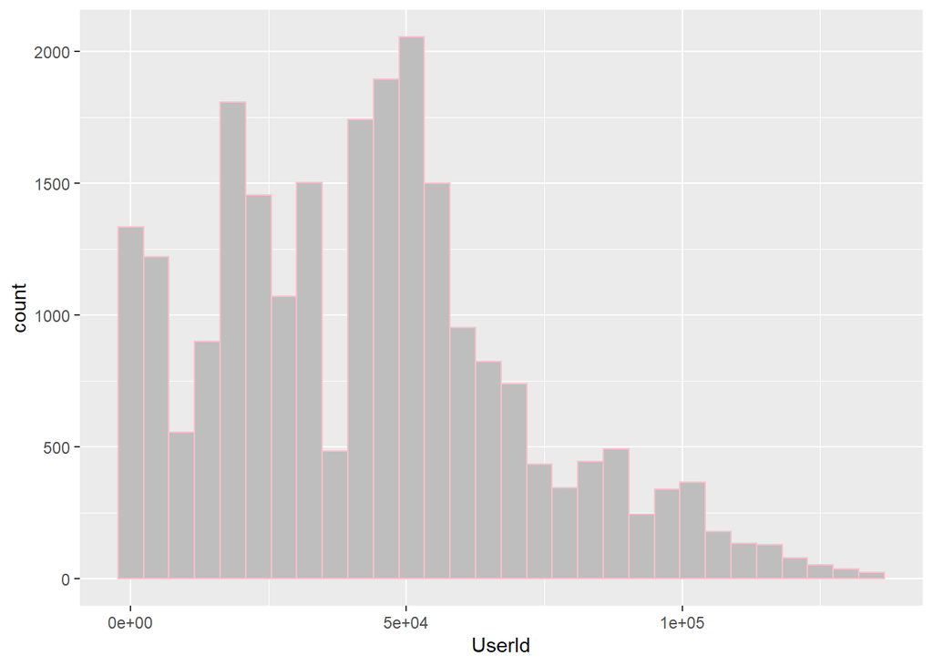

```r
ggplot(dane, aes(x=UserId)) +
  geom_histogram(color="pink", fill="grey")
```

**c. Podstawowe statystyki opisowe dla zmiennych:**

```r
dane$StyleID <- as.factor(dane$StyleID)
dane$IBU<-as.factor(dane$IBU)
dane$Color<-as.factor(dane$Color)
dane$Efficiency<-as.factor(dane$Efficiency)
dane$PrimaryTemp <- as.factor(dane$PrimaryTemp)
dane$UserId<-as.factor(dane$UserId)
dane<-dane[-c(24,25,26,27)]
summary(dane)
```

```
##      BeerID                  Name
##  1      :    1   Awesome Recipe: 1311
##  2      :    1   IPA           :  197
##  3      :    1   Saison        :  181
##  4      :    1   Kölsch        :  173
##  5      :    1   Black IPA     :  129
##  6      :    1   (Other)       :71869
##  (Other):73855   NA's          :    1
##                                                 URL
##  /homebrew/recipe/view/10003/yuen-porter-clone    :    1
##  /homebrew/recipe/view/100034/double-dog-citra-ipa:    1
##  /homebrew/recipe/view/100068/hop-rocket          :    1
##  /homebrew/recipe/view/100096/evie-pale-ale-ag    :    1
##  /homebrew/recipe/view/100147/battle-of-flodden   :    1
##  /homebrew/recipe/view/10022/california-apa       :    1
##  (Other)                                          :73855
##                   Style          StyleID         Size.L.              OG
##  American IPA        :11940   7      :11940   Min.   :   1.00   Min.   :1.004
##  American Pale Ale   : 7581   10     : 7581   1st Qu.:  18.93   1st Qu.:1.004
##  Saison              : 2617   134    : 2617   Median :  20.82   Median :1.004
##  American Light Lager: 2277   9      : 2277   Mean   :  43.93   Mean   :1.005
##  American Amber Ale  : 2038   4      : 2038   3rd Qu.:  23.66   3rd Qu.:1.004
##  (Other)             :46812   30     : 1753   Max.   :9200.00   Max.   :1.149
##  NA's                :  596   (Other):45655
##        FG             ABV              IBU            Color
##  Min.   :1.000   Min.   : 0.000   0      : 4159   50     : 1516
##  1st Qu.:1.004   1st Qu.: 5.080   18.89  :   99   40     :  702
##  Median :1.004   Median : 5.790   20.78  :   99   3.59   :  240
##  Mean   :1.004   Mean   : 6.137   23.08  :   96   3.86   :  185
##  3rd Qu.:1.004   3rd Qu.: 6.830   18.47  :   70   5.1    :  173
##  Max.   :1.098   Max.   :54.720   20.99  :   66   4.38   :  161
##                                   (Other):69272   (Other):70884
##     BoilSize          BoilTime       BoilGravity      Efficiency
##  Min.   :   1.00   Min.   :  0.00   Min.   :1.000   70     :21298
##  1st Qu.:  20.82   1st Qu.: 60.00   1st Qu.:1.004   75     :13679
##  Median :  27.44   Median : 60.00   Median :1.004   35     : 8593
##  Mean   :  49.73   Mean   : 65.07   Mean   :1.005   65     : 5162
##  3rd Qu.:  30.00   3rd Qu.: 60.00   3rd Qu.:1.004   80     : 3878
##  Max.   :9700.00   Max.   :240.00   Max.   :1.248   60     : 3163
##                                     NA's   :2990    (Other):18088
```

[output cut: 9 more lines]

```
##  Min.   :0.00    20     :14185   Corn Sugar:  715   5 oz   :  205
##  1st Qu.:0.35    21.11  : 4622   Dextrose  :  503   3/4 cup:  110
##  Median :0.75    18.33  : 4182   corn sugar:  360   4 oz   :  106
##  Mean   :0.75    18     : 4129   Keg       :  330   1 cup  :  102
##  3rd Qu.:1.00    19     : 2674   Sugar     :  312   5oz    :   92
##  Max.   :2.00    (Other):21407   (Other)   : 4546   (Other): 4161
##  NA's   :39252   NA's   :22662   NA's      :67095   NA's   :69085
##      UserId
##  34210  :  319
##  18665  :  224
##  18325  :  210
##  5889   :  195
##  5100   :  162
##  (Other):22261
##  NA's   :50490
```

**Wniosek** Ze względu na cel badania powinny zostać wyeliminowane zmienne: BeerID, Name, URL, UserId oraz zmienna Style, ponieważ w zbiorze znajduje się już zmienna StyleID, która już informuje na jaki styl piwa jest dany przepis. Wskazane zmienne nie mają wpływu na objaśnianie procentowej zawartości alkoholu w piwie. Plik wgrany jako `danes` nie będzie wykorzystywany, ponieważ powiela informacje, które znajdują się już w danych wgranych jako `dane`.

*3. Imputacje braków danych. Zastosowanie wybranej metody imputacji danych, z uzasadnieniem wyboru.*

**Wszystkie zmienne ze zbioru zostały poddane analizie braków**

**Liczba braków dla poszczególnych zmiennych oraz kombinacje braków danych**

```r
 summary(aggr(dane, plot=FALSE))
```

```
##
##  Missings per variable:
##       Variable Count
##         BeerID     0
##           Name     1
##            URL     0
##          Style   596
##        StyleID     0
##        Size.L.     0
##             OG     0
##             FG     0
##            ABV     0
##            IBU     0
##          Color     0
##       BoilSize     0
##       BoilTime     0
##    BoilGravity  2990
##     Efficiency     0
##  MashThickness 29864
##     SugarScale     0
##     BrewMethod     0
##      PitchRate 39252
##    PrimaryTemp 22662
##  PrimingMethod 67095
##  PrimingAmount 69085
##         UserId 50490
##
##  Missings in combinations of variables:
##                                   Combinations Count      Percent
##  0:0:0:0:0:0:0:0:0:0:0:0:0:0:0:0:0:0:0:0:0:0:0   757  1.024898119
##  0:0:0:0:0:0:0:0:0:0:0:0:0:0:0:0:0:0:0:0:0:0:1   791  1.070930532
##  0:0:0:0:0:0:0:0:0:0:0:0:0:0:0:0:0:0:0:0:0:1:0   396  0.536142213
##  0:0:0:0:0:0:0:0:0:0:0:0:0:0:0:0:0:0:0:0:0:1:1   456  0.617375882
##  0:0:0:0:0:0:0:0:0:0:0:0:0:0:0:0:0:0:0:0:1:0:0    13  0.017600628
##  0:0:0:0:0:0:0:0:0:0:0:0:0:0:0:0:0:0:0:0:1:0:1    11  0.014892839
##  0:0:0:0:0:0:0:0:0:0:0:0:0:0:0:0:0:0:0:0:1:1:0  5887  7.970376789
##  0:0:0:0:0:0:0:0:0:0:0:0:0:0:0:0:0:0:0:0:1:1:1 11988 16.230486996
##  0:0:0:0:0:0:0:0:0:0:0:0:0:0:0:0:0:0:0:1:0:0:0    25  0.033847362
##  0:0:0:0:0:0:0:0:0:0:0:0:0:0:0:0:0:0:0:1:0:0:1    27  0.036555151
##  0:0:0:0:0:0:0:0:0:0:0:0:0:0:0:0:0:0:0:1:0:1:0    22  0.029785679
```

[output cut: 91 more lines]

```
##  0:0:0:1:0:0:0:0:0:0:0:0:0:0:0:1:0:0:0:1:1:1:1     1  0.001353894
##  0:0:0:1:0:0:0:0:0:0:0:0:0:0:0:1:0:0:1:0:0:0:0     4  0.005415578
##  0:0:0:1:0:0:0:0:0:0:0:0:0:0:0:1:0:0:1:0:0:0:1     2  0.002707789
##  0:0:0:1:0:0:0:0:0:0:0:0:0:0:0:1:0:0:1:0:1:1:0     7  0.009477261
##  0:0:0:1:0:0:0:0:0:0:0:0:0:0:0:1:0:0:1:0:1:1:1    31  0.041970729
##  0:0:0:1:0:0:0:0:0:0:0:0:0:0:0:1:0:0:1:1:0:0:0     2  0.002707789
##  0:0:0:1:0:0:0:0:0:0:0:0:0:0:0:1:0:0:1:1:0:1:0     1  0.001353894
##  0:0:0:1:0:0:0:0:0:0:0:0:0:0:0:1:0:0:1:1:1:1:0    11  0.014892839
##  0:0:0:1:0:0:0:0:0:0:0:0:0:0:0:1:0:0:1:1:1:1:1    33  0.044678518
##  0:0:0:1:0:0:0:0:0:0:0:0:0:1:0:0:0:0:1:1:1:1:1     2  0.002707789
##  0:0:0:1:0:0:0:0:0:0:0:0:0:1:0:1:0:0:0:0:1:1:0     2  0.002707789
##  0:0:0:1:0:0:0:0:0:0:0:0:0:1:0:1:0:0:1:0:1:1:0     2  0.002707789
##  0:0:0:1:0:0:0:0:0:0:0:0:0:1:0:1:0:0:1:1:1:1:0    10  0.013538945
##  0:0:0:1:0:0:0:0:0:0:0:0:0:1:0:1:0:0:1:1:1:1:1   226  0.305980152
##  0:1:0:0:0:0:0:0:0:0:0:0:0:0:0:0:0:0:0:0:1:1:1     1  0.001353894
```

**Wniosek:** Ponieważ zmienna URL nie ma wpływu na badane zjawisko, do którego przygotowywane są dane oraz nie posiada braków, zostanie na tym etapie wyeliminowana. Zmienna Name posiada jeden brak, ale również jest nieprzydatna zważywszy na cel badania, więc również zostaje wyeliminowana. Zmienna BeerID pozostanie w zbiorze do etapu 4 włącznie, dla celów identyfikacji danego rekordu. Zmienna SugarScale, również zostanie usunięta, ponieważ nie posiada braków oraz zmienne, które były zapisane jako typ `Plato` zostały przekonwertowane w etapie 2 na typ `Specific Gravity`, więc zmienna jest już bezużyteczna.

*Ponowne wczytanie danych po usunięciu zmiennych*

```r
dane1 <- subset(dane,select = -c(Name, URL, SugarScale))
head(dane1,10)
```

```
##    BeerID                              Style StyleID Size.L.    OG    FG  ABV
## 1       1                          Cream Ale      45   21.77 1.004 1.004 5.48
## 2       2 Holiday/Winter Special Spiced Beer      85   20.82 1.004 1.004 8.16
## 3       3                       American IPA       7   18.93 1.004 1.004 5.91
## 4       4                       American IPA       7   22.71 1.004 1.004 5.80
## 5       5                  Belgian Blond Ale      20   50.00 1.004 1.004 6.48
## 6       6                  American Pale Ale      10   24.61 1.004 1.004 5.58
## 7       7                       Imperial IPA      86   22.71 1.004 1.004 7.09
## 8       8                          Cream Ale      45   20.82 1.004 1.004 5.36
## 9       9                      Robust Porter     129   22.71 1.004 1.004 5.77
## 10     10                       Imperial IPA      86   20.82 1.004 1.004 8.22
##       IBU Color BoilSize BoilTime BoilGravity Efficiency MashThickness
## 1   17.65  4.83    28.39       75       1.004         70            NA
## 2   60.65 15.64    24.61       60       1.004         70            NA
## 3   59.25  8.98    22.71       60          NA         70            NA
```

[output cut: 18 more lines]

**Sprawdzenie czy zmienne są zapisane w postaci data frame**

```r
str(dane1)
```

```
## 'data.frame':    73861 obs. of  20 variables:
##  $ BeerID       : Factor w/ 73861 levels "1","2","3","4",..: 1 2 3 4 5 6 7 8 9 10 ...
##  $ Style        : Factor w/ 175 levels "Altbier","Alternative Grain Beer",..: 45 85 7 7 20 10 86 45 128 86 ...
##  $ StyleID      : Factor w/ 176 levels "1","2","3","4",..: 45 85 7 7 20 10 86 45 129 86 ...
##  $ Size.L.      : num  21.8 20.8 18.9 22.7 50 ...
##  $ OG           : num  1 1 1 1 1 ...
##  $ FG           : num  1 1 1 1 1 ...
##  $ ABV          : num  5.48 8.16 5.91 5.8 6.48 5.58 7.09 5.36 5.77 8.22 ...
##  $ IBU          : Factor w/ 12587 levels "0","0.01","0.04",..: 1453 5749 5610 5136 1472 3700 12383 1685 2851 8776 ...
##  $ Color        : Factor w/ 4729 levels "0","0.02","0.03",..: 367 1448 782 734 341 684 517 478 3351 713 ...
##  $ BoilSize     : num  28.4 24.6 22.7 26.5 60 ...
##  $ BoilTime     : num  75 60 60 60 90 70 90 75 75 60 ...
##  $ BoilGravity  : num  1 1 NA NA 1 ...
##  $ Efficiency   : Factor w/ 272 levels "0","0.8","1",..: 162 162 162 162 174 217 193 162 181 162 ...
##  $ MashThickness: num  NA NA NA NA NA NA NA 1.4 NA NA ...
##  $ BrewMethod   : Factor w/ 4 levels "All Grain","BIAB",..: 1 1 3 1 1 1 1 1 1 1 ...
##  $ PitchRate    : num  NA NA NA NA NA 1 NA NA NA NA ...
##  $ PrimaryTemp  : Factor w/ 217 levels "-17.78","-14.44",..: 94 NA NA NA 111 NA NA NA NA 129 ...
##  $ PrimingMethod: Factor w/ 874 levels " ??????"," 40g/5 US G / 19L. -Brew sugar",..: 266 NA NA NA 803 NA NA 266 266 269 ...
##  $ PrimingAmount: Factor w/ 1897 levels "---"," @ 15 psi",..: 1203 NA NA NA 1442 NA NA 1178 1149 1220 ...
##  $ UserId       : Factor w/ 2785 levels "49","87","97",..: 4 57 NA NA 461 203 66 4 4 NA ...
```

**Wizualizacja braków danych i wzoru braków danych** * *Wykres 1* - Procentowa ilość braków danych u poszczególnych zmiennych * *Wykres 2* - Wzór braków danych - występowanie braków pomiędzy rekaordami tzn, równoczesnie dla poniższych zmiennych

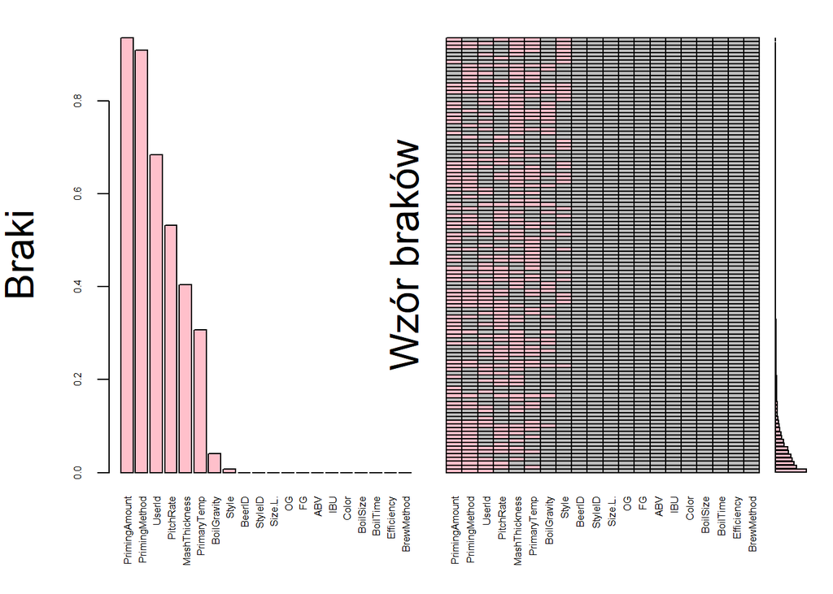

```
##
##  Variables sorted by number of missings:
##       Variable       Count
##  PrimingAmount 0.935338000
##  PrimingMethod 0.908395500
##         UserId 0.683581322
##      PitchRate 0.531430660
##  MashThickness 0.404327047
##    PrimaryTemp 0.306819566
##    BoilGravity 0.040481445
##          Style 0.008069211
##         BeerID 0.000000000
##        StyleID 0.000000000
##        Size.L. 0.000000000
##             OG 0.000000000
##             FG 0.000000000
##            ABV 0.000000000
##            IBU 0.000000000
##          Color 0.000000000
##       BoilSize 0.000000000
##       BoilTime 0.000000000
##     Efficiency 0.000000000
##     BrewMethod 0.000000000
```

```r
plot_missing<-aggr(dane1, col=c('grey','pink'),
                   numbers=TRUE, sortVars=TRUE,
                   labels=names(dane1), cex.axis=0.5,
                   cex.lab=2,
                   gap=1, ylab=c('Braki',"Wzór braków"))
```

**Wniosek** Ponieważ zmienne PrimingAmount, PrimingMethod, UserId i PitchRate posiadają ponad 50% brakujących danych na tym etapie zostają wyeliminowane i nie będą brane pod uwagę w dalszej części przygotowania danych. Zmienna Style także zostaje wyeliminowana, ponieważ jak wcześniej wspomniano w zbiorze jest już zmienna StyleID, która nie posiada braków.

*Ponowne wczytanie danych po usunięciu wyeliminowanych zmiennych*

```r
dane2 <- subset(dane1,select = -c(PrimingAmount, PrimingMethod, UserId, PitchRate, Style))
head(dane2,10)
```

```
##    BeerID StyleID Size.L.    OG    FG  ABV    IBU Color BoilSize BoilTime
## 1       1      45   21.77 1.004 1.004 5.48  17.65  4.83    28.39       75
## 2       2      85   20.82 1.004 1.004 8.16  60.65 15.64    24.61       60
## 3       3       7   18.93 1.004 1.004 5.91  59.25  8.98    22.71       60
## 4       4       7   22.71 1.004 1.004 5.80  54.48   8.5    26.50       60
## 5       5      20   50.00 1.004 1.004 6.48  17.84  4.57    60.00       90
## 6       6      10   24.61 1.004 1.004 5.58  40.12     8    29.34       70
## 7       7      86   22.71 1.004 1.004 7.09 268.71  6.33    30.28       90
## 8       8      45   20.82 1.004 1.004 5.36  19.97  5.94    28.39       75
## 9       9     129   22.71 1.004 1.004 5.77  31.63 34.76    30.28       75
## 10     10      86   20.82 1.004 1.004 8.22  93.02  8.29    28.39       60
##    BoilGravity Efficiency MashThickness BrewMethod PrimaryTemp
## 1        1.004         70            NA  All Grain       17.78
## 2        1.004         70            NA  All Grain        <NA>
## 3           NA         70            NA    extract        <NA>
## 4           NA         70            NA  All Grain        <NA>
## 5        1.004         72            NA  All Grain          19
## 6        1.004         79            NA  All Grain        <NA>
## 7           NA         75            NA  All Grain        <NA>
## 8        1.004         70           1.4  All Grain        <NA>
## 9        1.004         73            NA  All Grain        <NA>
## 10       1.004         70            NA  All Grain       21.11
```

**BoilGravity - imputacja braków danych średnią arytmetyczną, ponieważ jest to skala ilorazowa i nie ma ograniczeń na operacje matematyczne**

```r
dane2$BoilGravity<-as.numeric(dane2$BoilGravity)
dane2<-dane2%>%
  mutate(BoilGravity_1=if_else(is.na(BoilGravity), mean(BoilGravity,na.rm = T), BoilGravity))
dane2$BoilGravity_1<-round(dane2$BoilGravity_1,3)
#odchylenie standardowe przed imputacją
sd(dane2$BoilGravity, na.rm=T)
```

```
## [1] 0.00794226
```

```r
#odchylenie standardowe po imputacji
sd(dane2$BoilGravity_1, na.rm=T)
```

```
## [1] 0.007779977
```

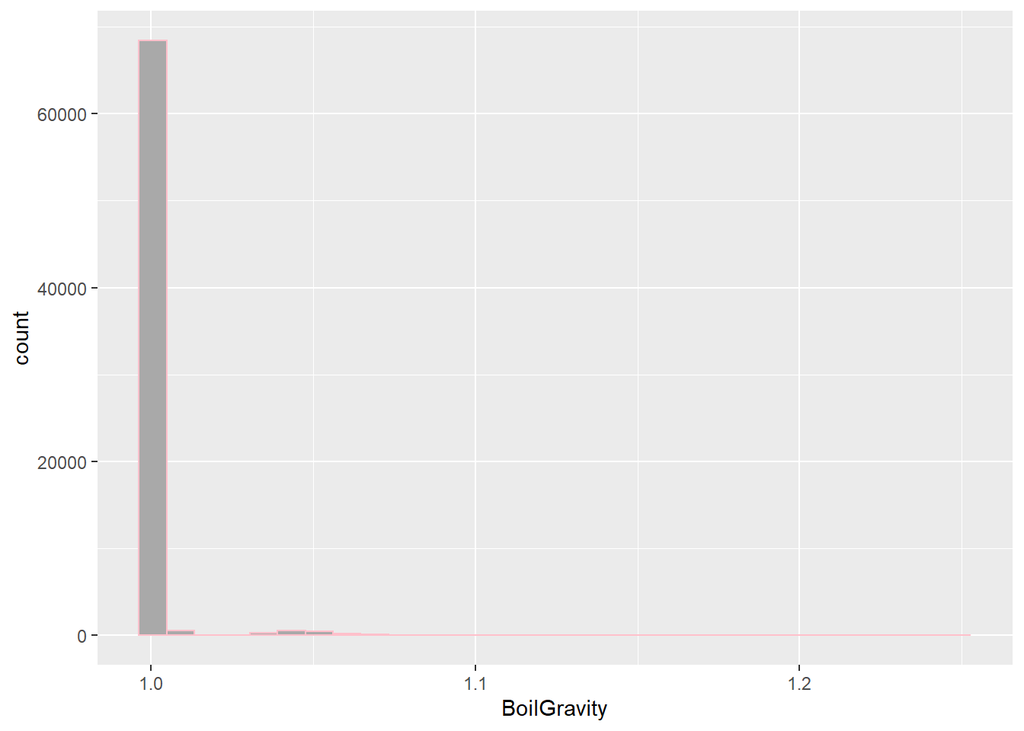

```r
#wykres przed imputacją
ggplot(dane2, aes(x=BoilGravity)) +
  geom_histogram(color="pink", fill="darkgrey")
```

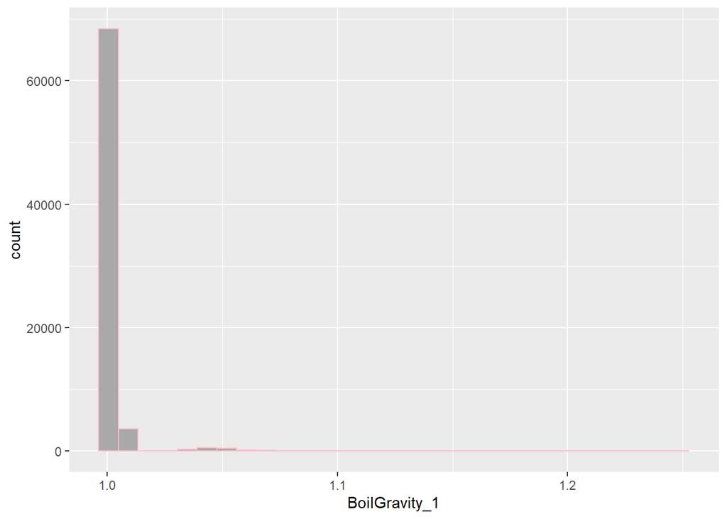

```r
#wykres po imputacji
ggplot(dane2, aes(x=BoilGravity_1)) +
  geom_histogram(color="pink", fill="darkgrey")
```

**MashThickness - imputacja braków danych średnią arytmetyczną, ponieważ jest to skala ilorazowa i nie ma ograniczeń na operacje matematyczne**

```r
dane2$MashThickness<-as.numeric(dane2$MashThickness)
dane2<-dane2%>%
  mutate(MashThickness_1=if_else(is.na(MashThickness), mean(MashThickness,na.rm = T), MashThickness))
dane2$MashThickness_1<-round(dane2$MashThickness_1,3)
#odchylenie standardowe przed imputacją
sd(dane2$MashThickness, na.rm=T)
```

```
## [1] 1.682347
```

```r
#odchylenie standardowe po imputacji
sd(dane2$MashThickness_1, na.rm=T)
```

```
## [1] 1.298427
```

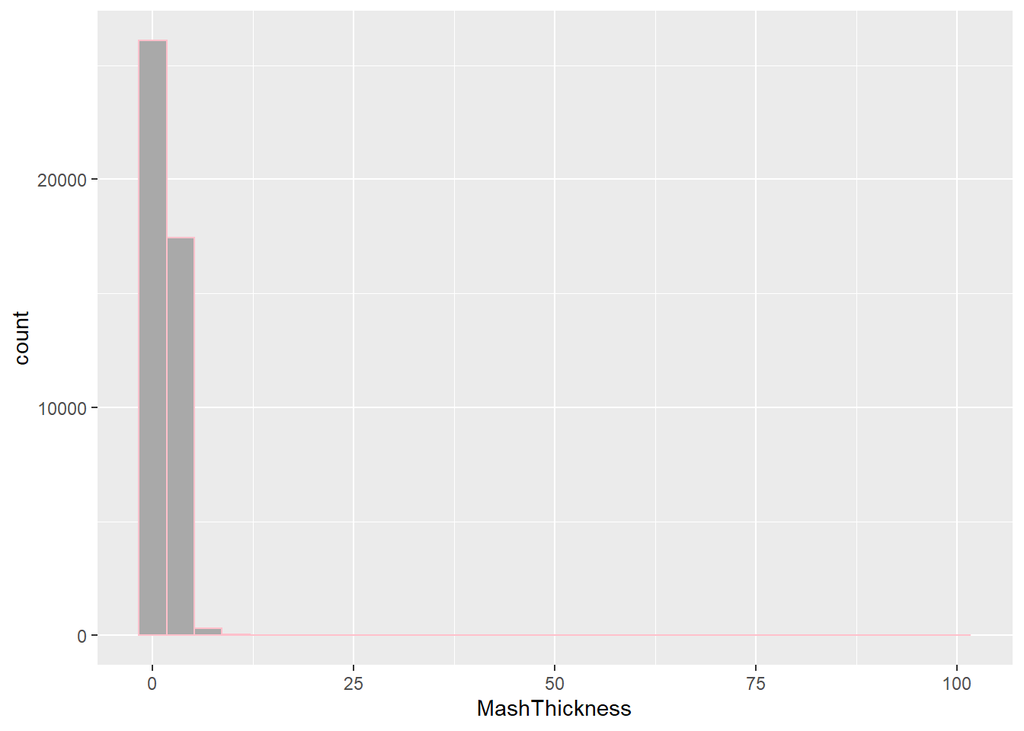

```r
#wykres przed imputacją
ggplot(dane2, aes(x=MashThickness)) +
  geom_histogram(color="pink", fill="darkgrey")
```

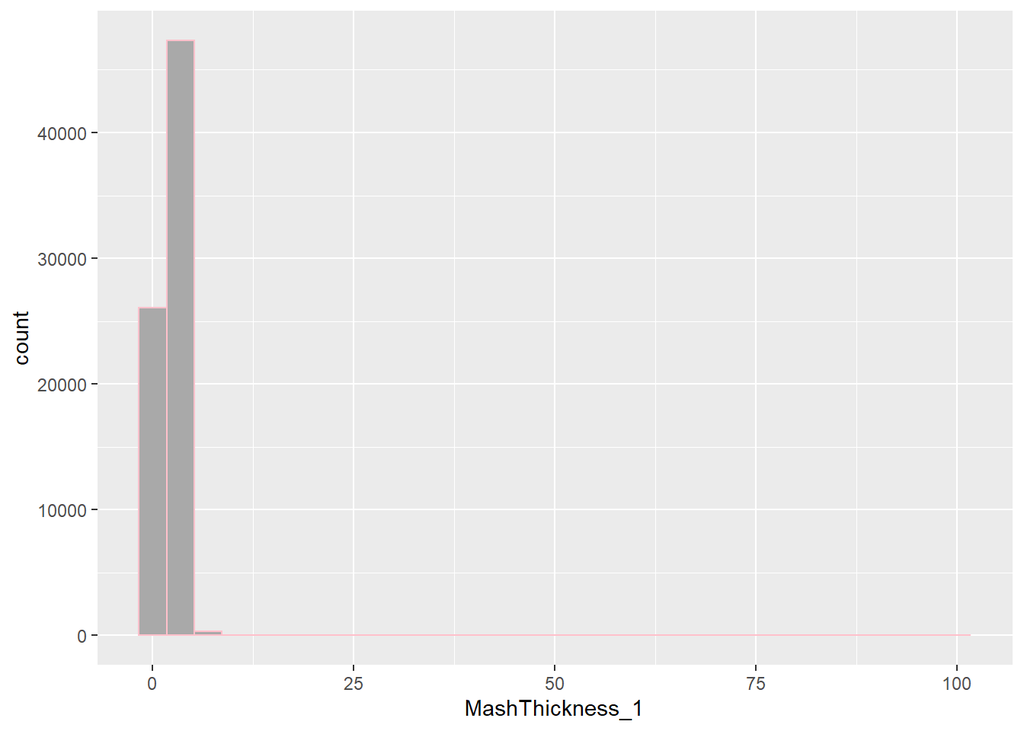

```r
#wykres po imputacji
ggplot(dane2, aes(x=MashThickness_1)) +
  geom_histogram(color="pink", fill="darkgrey")
```

**PrimaryTemp - imputacja braków danych za pomocą mediany, ponieważ jest to skala przedziałowa i nie można na niej wykonywać operacji dzielenia tzn. obliczenia średniej**

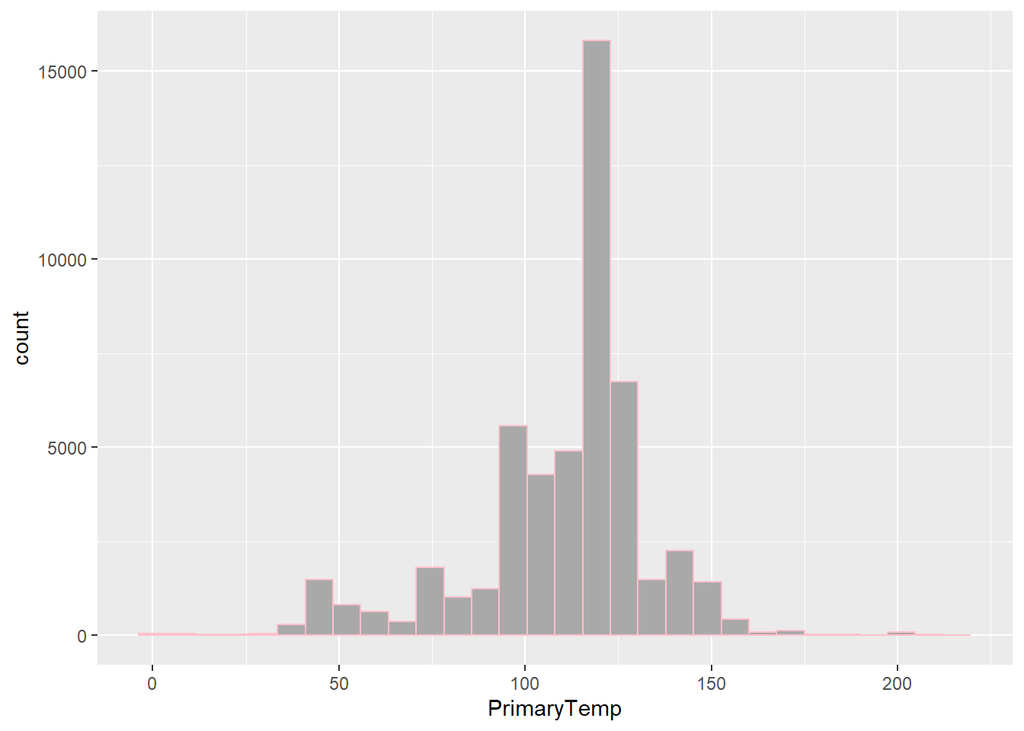

```r
dane2$PrimaryTemp<-as.numeric(dane2$PrimaryTemp)
dane2<-dane2%>%
  mutate(PrimaryTemp_1=if_else(is.na(PrimaryTemp), median(PrimaryTemp,na.rm = T), PrimaryTemp))
dane2$PrimaryTemp_1<-round(dane2$PrimaryTemp_1,3)
#wykres przed imputacją
ggplot(dane2, aes(x=PrimaryTemp)) +
  geom_histogram(color="pink", fill="darkgrey")
```

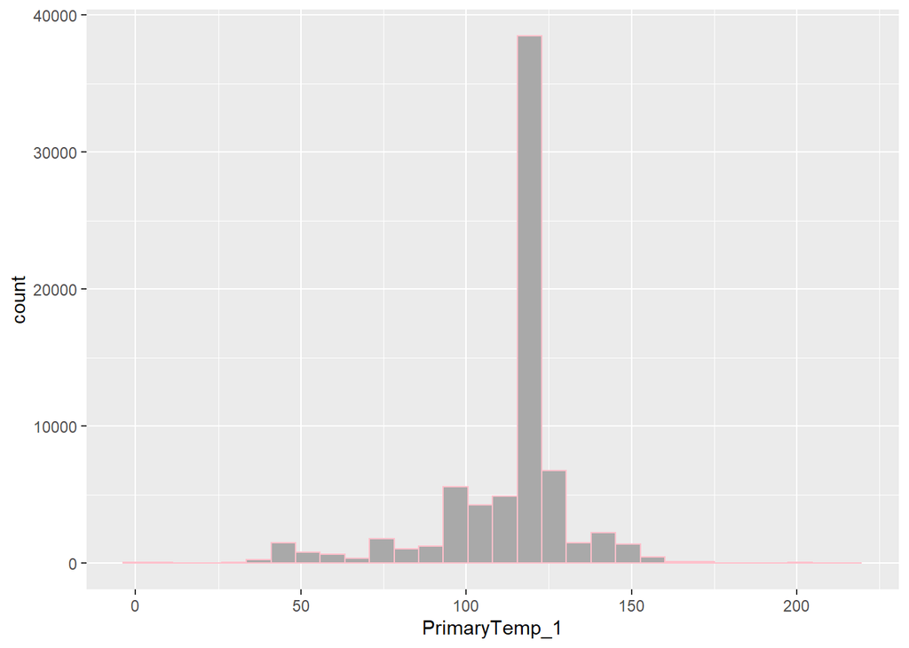

```r
#wykres po imputacji
ggplot(dane2, aes(x=PrimaryTemp_1)) +
  geom_histogram(color="pink", fill="darkgrey")
```

**Przypisanie zimputowanych danych do nazw pierwotnych zmiennych**

```r
dane2$BoilGravity<-as.numeric(dane2$BoilGravity_1)
dane2$MashThickness<-as.numeric(dane2$MashThickness_1)
dane2$PrimaryTemp<-as.factor(dane2$PrimaryTemp_1)
```

**Sprawdzenie poprawności imputacji - czy nie ma żadnych braków**

```r
dane2 <- subset(dane2,select = -c(BoilGravity_1, MashThickness_1, PrimaryTemp_1))
NA_count <- colSums(is.na(dane2))
NA_count
```

```
##        BeerID       StyleID       Size.L.            OG            FG
##             0             0             0             0             0
##           ABV           IBU         Color      BoilSize      BoilTime
##             0             0             0             0             0
##   BoilGravity    Efficiency MashThickness    BrewMethod   PrimaryTemp
##             0             0             0             0             0
```

**Wniosek:** Nie ma żadnych braków danych, można przejść do analizy wartości skrajnych.

*4. Analiza wartości skrajnych:*

*Analiza wartości skrajnych została wykonana za pomocą średniej i odchylenia standardowego. Przed analizą sprawdzono za pomocą testu Kołmogorowa-Smirnowa czy dana zmienna ma rozkład normalny. W analizie przyjęto, że zmienne są zbliżone do rozkładu normalnego.*

**a. Identyfikacja wartości skrajnych**

**Nadpisanie zmiennych**

```r
dane3<-dane2
```

**BeerID - zmienna nie podlega analizie wartości skrajnych, ponieważ jest to tylko identyfikator przepisu na piwo i nie może on być wartością skrajną lub nieskrajnych**

**StyleID - zmienna nie podlega analizie wartości skrajnych, ponieważ jest to tylko identyfikator stylu piwa i nie może on być wartością skrajną lub nieskrajnych**